# 2025.11.16-Wallmart_Project_Q2

### Capstone Project - Walmart Dataset

```python
# Importing basic Libraries

import numpy as np
import pandas as pd
import matplotlib.pyplot as plt
import seaborn as sns
from sklearn.metrics import accuracy_score

from sklearn.model_selection import train_test_split

import warnings
warnings.filterwarnings("ignore")
def fxn():
    warnings.warn("deprecated", DeprecationWarning)
with warnings.catch_warnings(action="ignore"):
    fxn()
```

```python
# importing the files
filepath = r"D:\Harpreet\Documents\Learning\Intellipaat- DS & AI 2025\ML\2025.11.16- Wallmart Project\Walmart_Dataset.csv"
walmart_df = pd.read_csv(filepath)
walmart_df
```

|  | Store | Date | Weekly_Sales | Holiday_Flag | Temperature | Fuel_Price | CPI | Unemployment |
| --- | --- | --- | --- | --- | --- | --- | --- | --- |
| 0 | 1 | 05-02-2010 | 1643690.90 | 0 | 42.31 | 2.572 | 211.096358 | 8.106 |
| 1 | 1 | 12-02-2010 | 1641957.44 | 1 | 38.51 | 2.548 | 211.242170 | 8.106 |
| 2 | 1 | 19-02-2010 | 1611968.17 | 0 | 39.93 | 2.514 | 211.289143 | 8.106 |
| 3 | 1 | 26-02-2010 | 1409727.59 | 0 | 46.63 | 2.561 | 211.319643 | 8.106 |
| 4 | 1 | 05-03-2010 | 1554806.68 | 0 | 46.50 | 2.625 | 211.350143 | 8.106 |
| ... | ... | ... | ... | ... | ... | ... | ... | ... |
| 6430 | 45 | 28-09-2012 | 713173.95 | 0 | 64.88 | 3.997 | 192.013558 | 8.684 |
| 6431 | 45 | 05-10-2012 | 733455.07 | 0 | 64.89 | 3.985 | 192.170412 | 8.667 |
| 6432 | 45 | 12-10-2012 | 734464.36 | 0 | 54.47 | 4.000 | 192.327265 | 8.667 |
| 6433 | 45 | 19-10-2012 | 718125.53 | 0 | 56.47 | 3.969 | 192.330854 | 8.667 |
| 6434 | 45 | 26-10-2012 | 760281.43 | 0 | 58.85 | 3.882 | 192.308899 | 8.667 |

6435 rows × 8 columns

```python
walmart_df['Holiday_Flag'].nunique()
```

```
2
```

**Observations**

- We have 45 stores. So to see performance of each store, we may need to take input of store number.
- It seems there is Temperature data also, indicating climatic conditions may be affecting the sales in some way.
- Weekly sales are given, there is a consistent span of 7 days of records. Weekly sales must be the amount of sales happened in that week span.
- CPI is the consumer price index, which indicates a ratio of consumption; sort of inflation factor. Probably indicating high CPI is high prices of Fuel.
- and parallelly, Uneployment rate may be a trend of records of the municipal.
- Probably the holiday flag may be that there might have been a holiday or more in the specific week.

```python
# Firstly we get a date index to begin with

walmart_df['Date']= pd.to_datetime(walmart_df['Date'], errors='coerce', format="%d-%m-%Y")  # converts the Date object to datetime format
                                                                                            # included the format parameter to avoid errors moving forward
walmart_df.set_index("Date", inplace=True)     # make the Date column as the index
# walmart_df.sort_index(inplace=True, ascending=True)    # sort as per ascending order

walmart_df.info()
```

```
<class 'pandas.core.frame.DataFrame'>
DatetimeIndex: 6435 entries, 2010-02-05 to 2012-10-26
Data columns (total 7 columns):
 #   Column        Non-Null Count  Dtype
---  ------        --------------  -----
 0   Store         6435 non-null   int64
 1   Weekly_Sales  6435 non-null   float64
 2   Holiday_Flag  6435 non-null   int64
 3   Temperature   6435 non-null   float64
 4   Fuel_Price    6435 non-null   float64
 5   CPI           6435 non-null   float64
 6   Unemployment  6435 non-null   float64
dtypes: float64(5), int64(2)
memory usage: 402.2 KB
```

We see in the .info that all the Dtypes are as needed.

```python
walmart_df.head()
```

| Date | Store | Weekly_Sales | Holiday_Flag | Temperature | Fuel_Price | CPI | Unemployment |
| --- | --- | --- | --- | --- | --- | --- | --- |
| 2010-02-05 | 1 | 1643690.90 | 0 | 42.31 | 2.572 | 211.096358 | 8.106 |
| 2010-02-12 | 1 | 1641957.44 | 1 | 38.51 | 2.548 | 211.242170 | 8.106 |
| 2010-02-19 | 1 | 1611968.17 | 0 | 39.93 | 2.514 | 211.289143 | 8.106 |
| 2010-02-26 | 1 | 1409727.59 | 0 | 46.63 | 2.561 | 211.319643 | 8.106 |
| 2010-03-05 | 1 | 1554806.68 | 0 | 46.50 | 2.625 | 211.350143 | 8.106 |

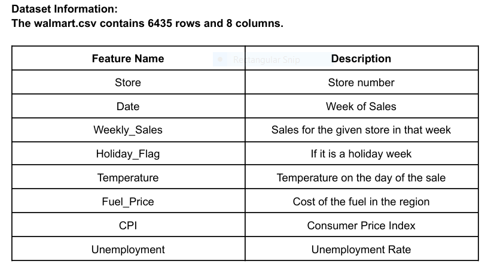

**1.** You are provided with the weekly sales data for their various outlets. Use statistical analysis, EDA, outlier analysis, and handle the missing values to come up with various insights that can give them a clear perspective on the following:

- a. If the weekly sales are affected by the unemployment rate, if yes - which stores are suffering the most?
- b. If the weekly sales show a seasonal trend, when and what could be the reason?
- c. Does temperature affect the weekly sales in any manner?
- d. How is the Consumer Price index affecting the weekly sales of various stores?
- e. Top performing stores according to the historical data.
- f. The worst performing store, and how significant is the difference between the highest and lowest performing stores.

**2.** Use predictive modeling techniques to forecast the sales for each store for the next 12 weeks.

### Here we will solve the Q2 of the given project, i.e. Predictive Model building exercise.

```python
# adding a Month number and Year number to the series, if we need it in ARIMAX or SARIMAX factoring

walmart_df['Month']= pd.DatetimeIndex(walmart_df.index).month   # extract the month number of the transaction
walmart_df['Year']= pd.DatetimeIndex(walmart_df.index).year     # extract the year number if the transaction
walmart_df.head()
```

| Date | Store | Weekly_Sales | Holiday_Flag | Temperature | Fuel_Price | CPI | Unemployment | Month | Year |
| --- | --- | --- | --- | --- | --- | --- | --- | --- | --- |
| 2010-02-05 | 1 | 1643690.90 | 0 | 42.31 | 2.572 | 211.096358 | 8.106 | 2 | 2010 |
| 2010-02-12 | 1 | 1641957.44 | 1 | 38.51 | 2.548 | 211.242170 | 8.106 | 2 | 2010 |
| 2010-02-19 | 1 | 1611968.17 | 0 | 39.93 | 2.514 | 211.289143 | 8.106 | 2 | 2010 |
| 2010-02-26 | 1 | 1409727.59 | 0 | 46.63 | 2.561 | 211.319643 | 8.106 | 2 | 2010 |
| 2010-03-05 | 1 | 1554806.68 | 0 | 46.50 | 2.625 | 211.350143 | 8.106 | 3 | 2010 |

```python
# Checking for duplicates or Null values

print(f"Duplicate items = {walmart_df.duplicated().sum()}")
print("---------------------")
print(f"Null Items : \n{walmart_df.isnull().sum()}")
```

```
Duplicate items = 0
---------------------
Null Items :
Store           0
Weekly_Sales    0
Holiday_Flag    0
Temperature     0
Fuel_Price      0
CPI             0
Unemployment    0
Month           0
Year            0
dtype: int64
```

Since there are 45 stores, we will split the data for different stores. We will take an input from the user for store numbers and then proceed for that selected store.

```python
number_of_stores= int(walmart_df['Store'].nunique())
print(f'Dataset contains complete data from {number_of_stores} stores.')
```

```
Dataset contains complete data from 45 stores.
```

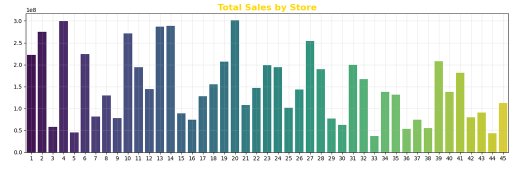

```python
plt.figure(figsize=(13,4.5))
store_sales = walmart_df.groupby('Store', as_index=False)['Weekly_Sales'].sum().sort_values(by='Weekly_Sales', ascending=False)

sns.barplot(
    data=store_sales,
    x='Store',
    y='Weekly_Sales',
    palette='viridis'
)

plt.title('Total Sales by Store', fontsize=16, color='gold', fontweight='semibold')
plt.xlabel('Store', fontsize=12, color='white')
plt.ylabel('Total Weekly Sales', fontsize=12, color='white')
plt.grid(alpha=0.3)
plt.tight_layout()
plt.show()
```

```python
# Since there are 45 Stores, we will obtain store number from the user

while True:
    try:
        store_number = int(input(f"Enter Store Number (1-{number_of_stores}): "))
        if 1 <= store_number <= number_of_stores:
            break
        else:
            print(f"Invalid input. Please enter a number between 1 and {number_of_stores}.")
    except ValueError:
        print("Invalid input. Please enter a valid integer.")

store= walmart_df[walmart_df.Store == store_number]
print(f'Selected Store Number is {store_number}')

store
```

```
Invalid input. Please enter a number between 1 and 45.
Invalid input. Please enter a number between 1 and 45.
Selected Store Number is 9
```

| Date | Store | Weekly_Sales | Holiday_Flag | Temperature | Fuel_Price | CPI | Unemployment | Month | Year |
| --- | --- | --- | --- | --- | --- | --- | --- | --- | --- |
| 2010-02-05 | 9 | 549505.55 | 0 | 38.01 | 2.572 | 214.655459 | 6.415 | 2 | 2010 |
| 2010-02-12 | 9 | 552677.48 | 1 | 37.08 | 2.548 | 214.805653 | 6.415 | 2 | 2010 |
| 2010-02-19 | 9 | 511327.90 | 0 | 43.06 | 2.514 | 214.850618 | 6.415 | 2 | 2010 |
| 2010-02-26 | 9 | 473773.27 | 0 | 43.83 | 2.561 | 214.878045 | 6.415 | 2 | 2010 |
| 2010-03-05 | 9 | 507297.88 | 0 | 48.43 | 2.625 | 214.905472 | 6.415 | 3 | 2010 |
| ... | ... | ... | ... | ... | ... | ... | ... | ... | ... |
| 2012-09-28 | 9 | 516361.06 | 0 | 76.80 | 3.666 | 226.763073 | 5.277 | 9 | 2012 |
| 2012-10-05 | 9 | 606755.30 | 0 | 66.61 | 3.617 | 226.966232 | 4.954 | 10 | 2012 |
| 2012-10-12 | 9 | 558464.80 | 0 | 60.09 | 3.601 | 227.169392 | 4.954 | 10 | 2012 |
| 2012-10-19 | 9 | 542009.46 | 0 | 68.01 | 3.594 | 227.214288 | 4.954 | 10 | 2012 |
| 2012-10-26 | 9 | 549731.49 | 0 | 69.52 | 3.506 | 227.232807 | 4.954 | 10 | 2012 |

143 rows × 9 columns

```python
store.describe()
```

|  | Store | Weekly_Sales | Holiday_Flag | Temperature | Fuel_Price | CPI | Unemployment | Month | Year |
| --- | --- | --- | --- | --- | --- | --- | --- | --- | --- |
| count | 143.0 | 143.000000 | 143.000000 | 143.000000 | 143.000000 | 143.000000 | 143.000000 | 143.000000 | 143.000000 |
| mean | 9.0 | 543980.552378 | 0.069930 | 67.775175 | 3.219699 | 219.626689 | 6.099881 | 6.447552 | 2010.965035 |
| std | 0.0 | 69028.666585 | 0.255926 | 15.614281 | 0.427313 | 4.440007 | 0.463083 | 3.249438 | 0.799759 |
| min | 9.0 | 452905.220000 | 0.000000 | 31.820000 | 2.514000 | 213.846982 | 4.954000 | 1.000000 | 2010.000000 |
| 25% | 9.0 | 506766.720000 | 0.000000 | 55.255000 | 2.764500 | 215.098948 | 5.667000 | 4.000000 | 2010.000000 |
| 50% | 9.0 | 536537.640000 | 0.000000 | 69.190000 | 3.290000 | 219.076855 | 6.384000 | 6.000000 | 2011.000000 |
| 75% | 9.0 | 560148.530000 | 0.000000 | 80.880000 | 3.594000 | 224.266502 | 6.416000 | 9.000000 | 2012.000000 |
| max | 9.0 | 905324.680000 | 1.000000 | 91.630000 | 3.907000 | 227.232807 | 6.560000 | 12.000000 | 2012.000000 |

For building a predictive model, we may not need all the data. Estimating from the weekly sales might give adequate results. We'll drop rest of the data. We'll keep the *Holiday Flag* column to see further how much affect it has on the sales.

```python
drop_cols= ['Store', 'Temperature', 'Fuel_Price', 'CPI', 'Unemployment', 'Month', 'Year']
store.drop(drop_cols, axis=1, inplace=True)
new_col_name= 'Weekly_Sales_Store-' + str(store_number)
store.rename(columns={'Weekly_Sales': new_col_name}, inplace=True)
store
```

| Date | Weekly_Sales_Store-9 | Holiday_Flag |
| --- | --- | --- |
| 2010-02-05 | 549505.55 | 0 |
| 2010-02-12 | 552677.48 | 1 |
| 2010-02-19 | 511327.90 | 0 |
| 2010-02-26 | 473773.27 | 0 |
| 2010-03-05 | 507297.88 | 0 |
| ... | ... | ... |
| 2012-09-28 | 516361.06 | 0 |
| 2012-10-05 | 606755.30 | 0 |
| 2012-10-12 | 558464.80 | 0 |
| 2012-10-19 | 542009.46 | 0 |
| 2012-10-26 | 549731.49 | 0 |

143 rows × 2 columns

Checking for outliers:

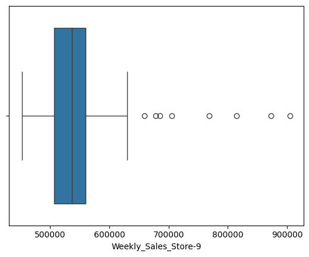

```python
sns.boxplot(x=store[new_col_name])
plt.show()
```

We see outliers.

```
Number of Outliers: 8
Data shape before cleaning: 143
Data shape after cleaning: 135
```

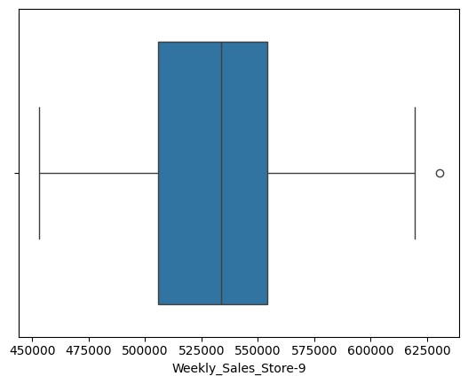

```python
Q1= store[new_col_name].quantile(0.25)
Q3= store[new_col_name].quantile(0.75)
IQR= Q3-Q1

lower_bound= Q1-(1.5*IQR)
upper_bound= Q3+(1.5*IQR)

outliers= store[(store[new_col_name] < lower_bound) | (store[new_col_name] > upper_bound)]
print(f"Number of Outliers: {outliers.shape[0]}")
print(f"Data shape before cleaning: {store.shape[0]}")

store= store[(store[new_col_name]>=lower_bound) & (store[new_col_name]<=upper_bound)]
print(f"Data shape after cleaning: {store.shape[0]}")

sns.boxplot(x=store[new_col_name])
plt.show()
```

```python
store.describe()
```

|  | Weekly_Sales_Store-9 | Holiday_Flag |
| --- | --- | --- |
| count | 135.000000 | 135.000000 |
| mean | 531111.633481 | 0.059259 |
| std | 40006.122555 | 0.236989 |
| min | 452905.220000 | 0.000000 |
| 25% | 505672.075000 | 0.000000 |
| 50% | 533756.880000 | 0.000000 |
| 75% | 554358.325000 | 0.000000 |
| max | 630327.280000 | 1.000000 |

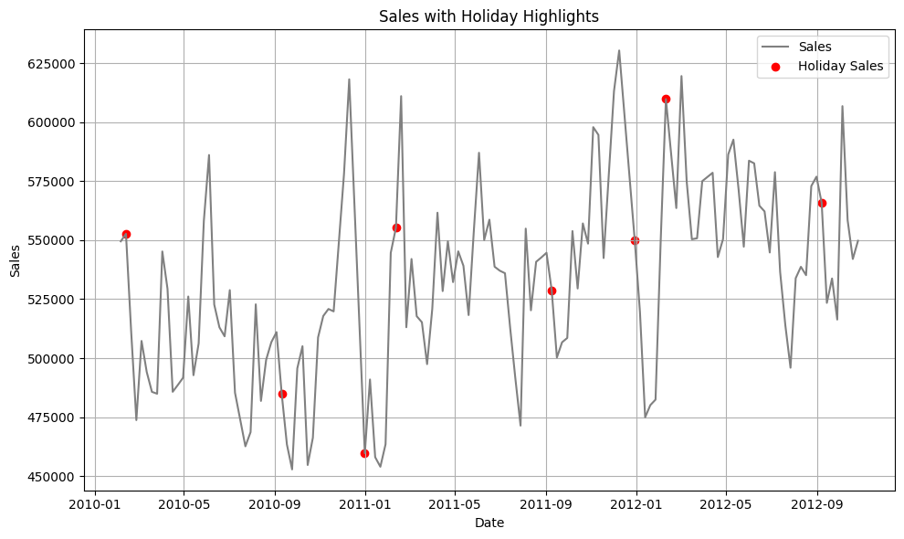

```python
plt.figure(figsize=(10,6))
plt.plot(store.index, store[new_col_name], color="gray", label="Sales")

# Highlight holidays
plt.scatter(store.index[store["Holiday_Flag"]==1], store[new_col_name][store["Holiday_Flag"]==1],
            color="red", label="Holiday Sales", marker="o")

plt.title("Sales with Holiday Highlights")
plt.xlabel("Date")
plt.ylabel("Sales")
plt.legend()
plt.grid(True)
plt.tight_layout()
plt.show()
```

We'll run a T-Test on holiday sales vs non-holiday sales

```python
from scipy.stats import ttest_ind

holiday_sales = store[store['Holiday_Flag'] == 1][new_col_name]
non_holiday_sales = store[store['Holiday_Flag'] == 0][new_col_name]

t_stat, p_value = ttest_ind(holiday_sales, non_holiday_sales, equal_var=False)

print('T-test : Holiday vs Non-Holiday Sales\n----------------------------')
print(f'T-Statistic : {t_stat:.4f}')
print(f'P-Value : {p_value:.4e}')

if p_value < 0.05:
    print(' There is significant difference between holiday and non-holiday sales')
else:
    print('There isnt any significant difference between holiday and non-holiday sales')
```

```
T-test : Holiday vs Non-Holiday Sales
----------------------------
T-Statistic : 0.4501
P-Value : 6.6512e-01
There isnt any significant difference between holiday and non-holiday sales
```

```
Seasonal Decomposition plots for Store No. 9
```

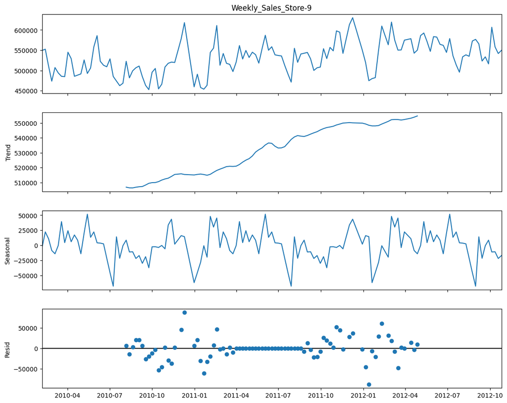

```python
from statsmodels.tsa.seasonal import seasonal_decompose

print(f"Seasonal Decomposition plots for Store No. {store_number}")
decomposition = seasonal_decompose(store[new_col_name], period=52)  # 52 weeks = 1 year
fig = plt.figure()
fig = decomposition.plot()
fig.set_size_inches(13, 10)
plt.show()
```

In most of the stores, consistent seasonility can be obeserved. For now, we can assume that all the stores are showing seasonality and we'll preceed further. In case seasonality is not observed in a certain store, please connect with the developer. Changes will be incorporated accorsdingly.

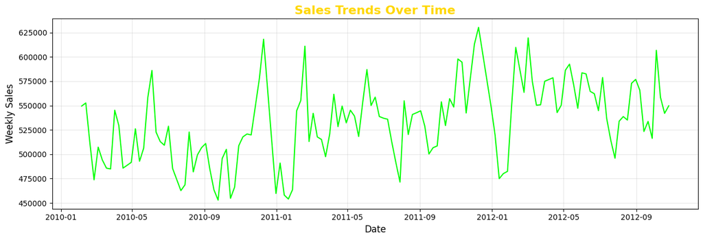

```python
# Check the Plot
# store.plot(figsize= (20,7))
# plt.legend()
# plt.show()

plt.figure(figsize=(13,4.5))
sns.lineplot(data=store, x='Date', y=new_col_name, color='lime', linewidth=1.5)

plt.title('Sales Trends Over Time', fontsize=16, color='gold', fontweight='semibold')
plt.xlabel('Date', fontsize=12)
plt.ylabel('Weekly Sales', fontsize=12)
plt.grid(alpha=0.3)
plt.tight_layout()
plt.show()
```

In most of the stores, the trend seems to be pretty linear. Though seasonility seems more prominient.  
Most of the show that The period between June to August shows a medium-high sales, while between December-January the sales are at peak.  
Some stores have a more consistent sales trend with the occassional high, while some show that around April-May, usually it is a lowest sales periods.

```python
# Running AD Fuller test

from statsmodels.tsa.stattools import adfuller
adf_result= adfuller(store[new_col_name])

# Display results
print("  AD-Fuller Test Results\n  -----------------------")
print("ADF Statistic:", adf_result[0])
print("p-value:", adf_result[1])
print("Critical Values:", adf_result[4])

# Hypothesis testing
print("\n\n Hypothesis Testing\n -------------------")
if(adf_result[1]>0.05):
    print(f"The data for store No. {store_number} is not stationary")
else:
    print(f"The data for store No. {store_number} is stationary")
```

```
  AD-Fuller Test Results
  -----------------------
ADF Statistic: -1.3862562424320986
p-value: 0.5888470256725093
Critical Values: {'1%': np.float64(-3.4851223522012855), '5%': np.float64(-2.88553750045158), '10%': np.float64(-2.5795685622144586)}


 Hypothesis Testing
 -------------------
The data for store No. 9 is not stationary
```

#### Model Building

ARIMA - p, d, q

- *ar* Auto Regression (past values) - p
- *i* differencing order / values - d
- *ma* Moving Averages (past errors) - q

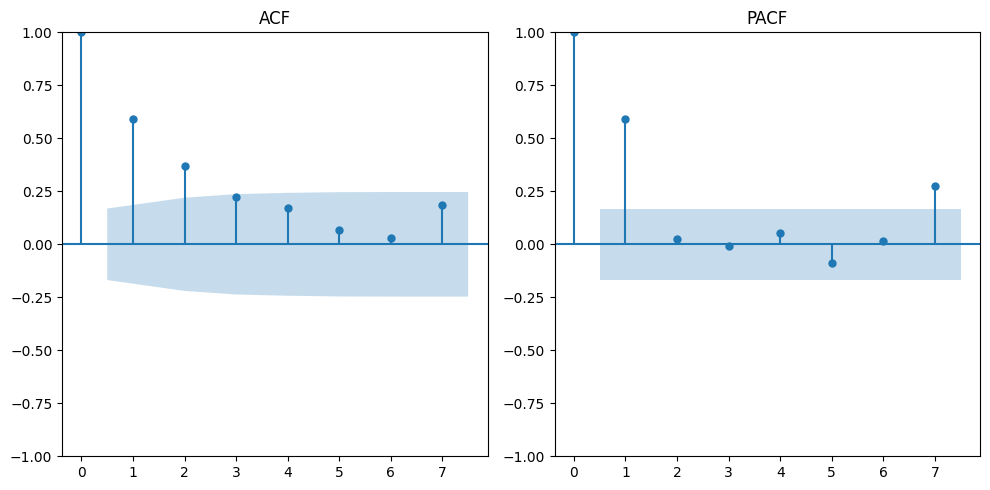

```python
# Trying to get an estimate of P & q from a graph

from statsmodels.graphics.tsaplots import plot_acf, plot_pacf

fig, axes= plt.subplots(1,2, figsize= (10,5))

plot_acf(store[new_col_name], ax=axes[0], lags=7)
axes[0].set_title("ACF")

plot_pacf(store[new_col_name], ax=axes[1], lags=7)
axes[1].set_title("PACF")

plt.tight_layout()
plt.show()
```

```python
# # For Running Iter tools, we split the data to train-test

train_size= int(len(store)*0.85)  # 85% is considered as the training size

train_df= store[new_col_name][:train_size]
test_df= store[new_col_name][train_size:]
```

```python
# taking last 52 weeks (1 year) as the test size, and all others as the training data

# train_df= store[:-52]
# test_df= store[-52:]
```

This train-test split was included later after the 80-20 split test runs because it's giving better predictions. Hence we will keep using this split.

```python
import itertools
from statsmodels.tsa.arima.model import ARIMA
from sklearn.metrics import mean_squared_error

p= range(0,10)  # Auto Regression (past values)
d= range(1,2)   # differencing order
q= range(0,9)   # moving average (past errors)

pdq= list(itertools.product(p,d,q))
rmse= []
order1= []

for i in pdq:
    model= ARIMA(train_df, order=i)
    model_fit= model.fit()
    pred= model_fit.predict(start= len(train_df), end= len(train_df)+len(test_df)-1)
    error= np.sqrt(mean_squared_error(test_df, pred))

    order1.append(i)
    rmse.append(error)

result = pd.DataFrame(index=order1, data=rmse, columns=["RMSE score"])
```

```python
result.sort_values(by='RMSE score', inplace=True)
```

```python
# fitting the calculated results into the model and observing the performance

best_model= result['RMSE score'].idxmin()
print(f'best factors for ARIMA is calculated at (p, d, q) = {best_model} for store No. {store_number}')
model1= ARIMA(store[new_col_name], order=best_model)
result= model1.fit()
store['ARIMA_Predicted']= result.predict()
store
```

```
best factors for ARIMA is calculated at (p, d, q) = (4, 1, 3) for store No. 9
```

| Date | Weekly_Sales_Store-9 | Holiday_Flag | ARIMA_Predicted |
| --- | --- | --- | --- |
| 2010-02-05 | 549505.55 | 0 | 0.000000 |
| 2010-02-12 | 552677.48 | 1 | 499625.375169 |
| 2010-02-19 | 511327.90 | 0 | 512345.672103 |
| 2010-02-26 | 473773.27 | 0 | 502971.932908 |
| 2010-03-05 | 507297.88 | 0 | 496815.387909 |
| ... | ... | ... | ... |
| 2012-09-28 | 516361.06 | 0 | 544230.786210 |
| 2012-10-05 | 606755.30 | 0 | 514598.581786 |
| 2012-10-12 | 558464.80 | 0 | 587567.371372 |
| 2012-10-19 | 542009.46 | 0 | 560755.301591 |
| 2012-10-26 | 549731.49 | 0 | 555728.990618 |

135 rows × 3 columns

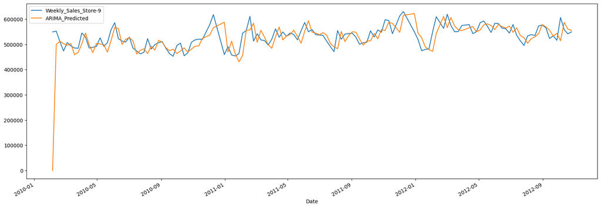

```python
store[[new_col_name, 'ARIMA_Predicted']].plot(figsize=(20,7))
plt.show()
```

#### **Predictions** using the ARIMA Model

```python
forecast_period = 12    # predict for 12 wekeks

forecast= result.get_forecast(steps=forecast_period)

forecast_value= forecast.predicted_mean
forecast_value
```

```
135    551663.314327
136    539441.143888
137    536122.876151
138    547599.027205
139    552471.838589
140    541924.003949
141    535658.732010
142    545097.664607
143    552566.626652
144    544381.254909
145    535908.865271
146    542722.651097
Name: predicted_mean, dtype: float64
```

### **SARIMA** Model building

to use PMDARIMA to automatically fit a Seasonal AutoRegressive Integrated Moving Average with eXogenous variables (SARIMAX) model to the weekly sales data, the parameters are set for automatic selection based on the Akaike Information Criterion (AIC) through the 'auto_arima' function as below:

```python
from pmdarima import auto_arima
```

```python
# Auto-ARIMA on store data
stepwise_fit= auto_arima(store[new_col_name],
                         seasonal=True,
                         m=52,
                         trace=False,
                         stepwise=True)
print(stepwise_fit.summary())

auto_arima_bestModel_store= stepwise_fit.order
print(f"best fit model: {stepwise_fit.order}")
```

```
                                     SARIMAX Results
==========================================================================================
Dep. Variable:                                  y   No. Observations:                  135
Model:             SARIMAX(1, 1, 1)x(0, 0, 1, 52)   Log Likelihood               -1587.574
Date:                            Sat, 13 Dec 2025   AIC                           3183.149
Time:                                    17:20:00   BIC                           3194.740
Sample:                                         0   HQIC                          3187.859
                                            - 135
Covariance Type:                              opg
==============================================================================
                 coef    std err          z      P>|z|      [0.025      0.975]
------------------------------------------------------------------------------
ar.L1          0.6355      0.105      6.065      0.000       0.430       0.841
ma.L1         -0.8049      0.101     -7.951      0.000      -1.003      -0.606
ma.S.L52      -0.1597      0.108     -1.479      0.139      -0.371       0.052
sigma2      1.171e+09   2.14e-11   5.47e+19      0.000    1.17e+09    1.17e+09
===================================================================================
Ljung-Box (L1) (Q):                   2.27   Jarque-Bera (JB):                14.25
Prob(Q):                              0.13   Prob(JB):                         0.00
Heteroskedasticity (H):               0.83   Skew:                            -0.17
Prob(H) (two-sided):                  0.55   Kurtosis:                         4.56
===================================================================================

Warnings:
[1] Covariance matrix calculated using the outer product of gradients (complex-step).
[2] Covariance matrix is singular or near-singular, with condition number 2.28e+35. Standard errors may be unstable.
best fit model: (1, 1, 1)
```

```python
# auto ARIMA on Training DF

stepwise_fit= auto_arima(train_df,
                         seasonal=True,
                         m=52,
                         trace=False,
                         stepwise=True)
print(stepwise_fit.summary())

auto_arima_bestModel_train= stepwise_fit.order
print(f"best fit model: {stepwise_fit.order}")
```

```
                                     SARIMAX Results
==========================================================================================
Dep. Variable:                                  y   No. Observations:                  114
Model:             SARIMAX(1, 1, 1)x(0, 0, 1, 52)   Log Likelihood               -1341.087
Date:                            Sat, 13 Dec 2025   AIC                           2690.175
Time:                                    17:21:19   BIC                           2701.085
Sample:                                         0   HQIC                          2694.602
                                            - 114
Covariance Type:                              opg
==============================================================================
                 coef    std err          z      P>|z|      [0.025      0.975]
------------------------------------------------------------------------------
ar.L1          0.6484      0.135      4.798      0.000       0.383       0.913
ma.L1         -0.7945      0.130     -6.131      0.000      -1.048      -0.540
ma.S.L52      -0.1643      0.123     -1.334      0.182      -0.406       0.077
sigma2      1.241e+09   2.51e-11   4.95e+19      0.000    1.24e+09    1.24e+09
===================================================================================
Ljung-Box (L1) (Q):                   1.89   Jarque-Bera (JB):                18.36
Prob(Q):                              0.17   Prob(JB):                         0.00
Heteroskedasticity (H):               1.20   Skew:                            -0.38
Prob(H) (two-sided):                  0.57   Kurtosis:                         4.82
===================================================================================

Warnings:
[1] Covariance matrix calculated using the outer product of gradients (complex-step).
[2] Covariance matrix is singular or near-singular, with condition number 6.82e+35. Standard errors may be unstable.
best fit model: (1, 1, 1)
```

```
best factors for ARIMA is calculated at (p, d, q) = (1, 1, 1) for store No. 9
```

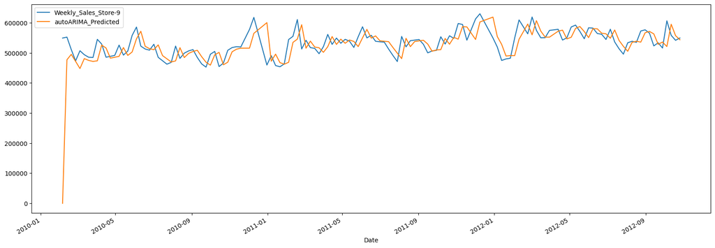

```python
# Checking the resul with Best model from Auto-ARIMA for store data

print(f'best factors for ARIMA is calculated at (p, d, q) = {auto_arima_bestModel_store} for store No. {store_number}')
model1= ARIMA(store[new_col_name], order=auto_arima_bestModel_store)
result= model1.fit()
store['autoARIMA_Predicted']= result.predict()

store[[new_col_name, 'autoARIMA_Predicted']].plot(figsize=(20,7))
plt.show()
```

```
best factors for ARIMA is calculated at (p, d, q) = (1, 1, 1) for store No. 9
```

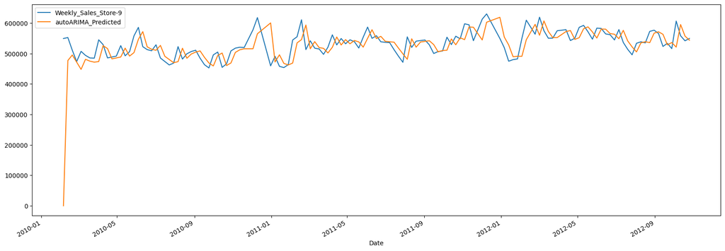

```python
# Checking the resul with Best model from Auto-ARIMA for store data

print(f'best factors for ARIMA is calculated at (p, d, q) = {auto_arima_bestModel_train} for store No. {store_number}')
model1= ARIMA(store[new_col_name], order=auto_arima_bestModel_train)
result= model1.fit()
store['autoARIMA_Predicted']= result.predict()

store[[new_col_name, 'autoARIMA_Predicted']].plot(figsize=(20,7))
plt.show()
```

```python
from statsmodels.tsa.statespace.sarimax import SARIMAX

sarima_model= SARIMAX(store[new_col_name], order=auto_arima_bestModel_store, seasonal_order=(1, 1, 1, 52))
sarima_result = sarima_model.fit(disp=False)

print(sarima_result.summary())
```

```
                                     SARIMAX Results
==========================================================================================
Dep. Variable:               Weekly_Sales_Store-9   No. Observations:                  135
Model:             SARIMAX(1, 1, 1)x(1, 1, 1, 52)   Log Likelihood                -989.446
Date:                            Sat, 13 Dec 2025   AIC                           1988.893
Time:                                    17:21:29   BIC                           2000.926
Sample:                                         0   HQIC                          1993.724
                                            - 135
Covariance Type:                              opg
==============================================================================
                 coef    std err          z      P>|z|      [0.025      0.975]
------------------------------------------------------------------------------
ar.L1          0.7106      0.410      1.732      0.083      -0.094       1.515
ma.L1         -0.8060      0.355     -2.270      0.023      -1.502      -0.110
ar.S.L52       0.1746      0.252      0.693      0.488      -0.319       0.668
ma.S.L52      -0.6459      0.506     -1.277      0.201      -1.637       0.345
sigma2      2.323e+09   4.66e-10   4.98e+18      0.000    2.32e+09    2.32e+09
===================================================================================
Ljung-Box (L1) (Q):                   0.27   Jarque-Bera (JB):                 2.92
Prob(Q):                              0.60   Prob(JB):                         0.23
Heteroskedasticity (H):               1.07   Skew:                             0.46
Prob(H) (two-sided):                  0.86   Kurtosis:                         2.92
===================================================================================

Warnings:
[1] Covariance matrix calculated using the outer product of gradients (complex-step).
[2] Covariance matrix is singular or near-singular, with condition number 1.97e+34. Standard errors may be unstable.
```

```python
# Forecast next 12 weeks
forecast_steps = 12
forecast = sarima_result.get_forecast(steps=forecast_steps)

forecast_mean = forecast.predicted_mean
forecast_ci = forecast.conf_int()

forecast_index = pd.date_range(start=store.index[-1] + pd.Timedelta(weeks=1), periods=forecast_steps, freq='W')
```

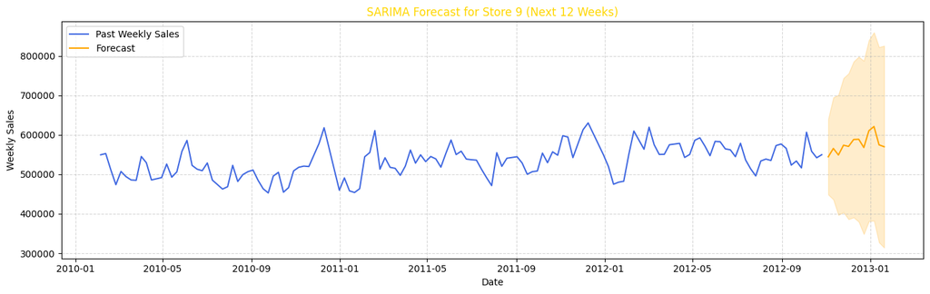

```python
plt.figure(figsize=(14,4.5))
plt.plot(store[new_col_name], color='royalblue', label='Past Weekly Sales')
plt.plot(forecast_index, forecast_mean, color='orange', label='Forecast')
plt.fill_between(forecast_index, forecast_ci.iloc[:,0], forecast_ci.iloc[:,1], color='orange', alpha=0.2)
plt.title(f'SARIMA Forecast for Store {store_number} (Next 12 Weeks)', color='gold')
plt.xlabel('Date')
plt.ylabel('Weekly Sales')
plt.legend()
plt.grid(True, linestyle='--', alpha=0.5)
plt.tight_layout()
plt.show()
```